# Data Preprocessing

# Introduction

Here I document the data preprocessing for this activity. Essentially what I want is a set of files that can be used to produce maps in a relatively simple way (at this point I don’t want to discuss the conversion of `Spatial*` and `Spatial*DataFrame` dataframes into the type of dataframes used by `ggmap`).

Therefore, I will convert the shape file into dataframes that students can readily use.

For this I will begin with the set of files (shape) called `Hamilton CMA tts06`

# Data preprocessing

Begin by loading the libraries needed to do this:

```r
library(rgdal)
library(readxl)
library(dplyr)
library(ggplot2)
library(tmap)
library(ggmap)
library(broom)
library(readr)
```

I can now proceed to see read the geospatial file.

For this example, I will use an ESRI shape file that contains the Traffic Analysis Zones for the Hamilton Census Metropolitan Area (CMA) (retrieved from [here](http://dmg.utoronto.ca/survey-boundary-files#2006_zone)). The command used for this is `rgdal::readOGR` (note that `package::function` indicates a function in the name package):

```r
taz <- readOGR(".", layer = "Hamilton CMA tts06")
```

This creates a `SpatialPolygonsDataFrame`, an R object used to store geographical information (in this example spatial polygons; other types of spatial data are points, lines, or pixels; more generally `Spatial*DataFrames`).

Now that I have a `SpatialPolygonDataFrame` object, I need to create a “tidy” version of it; in the present case this means the SpatialPolygonDataFrame `taz`. This is done by means of the `tidy` function of the `broom` package. We will call it `taz.t` for “tidy” (note that `tidy` needs to know the id that will be used to create the regions, that is, the spatial polygons; since this will be renamed `id` by `tidy`, we need to rename it to “GTA06” to keep it consistent with table data):

```r
taz.t <- tidy(taz, region = "GTA06")
#Rename id column
taz.t <- rename(taz.t, GTA06 = "id")
```

I have now a data frame that can be plotted in `ggmap`.

Next, for the activity, I want to create a few maps with strong spatial autocorrelation and with no autocorrelation. To do this, I will use the Moran Eigenvectors Map function `adespatial::mem`. First, load the package:

```r
library(spdep)
library(adespatial)
```

Before calculating the eigenvectors of the spatial weights matrix, I need a spatial weights matrix! The spatial weights matrix is obtained first by obtaining the nearest neighbors by contiguity using the `spdep::poly2nb` function:

```r
taznn <- poly2nb(taz, row.names = taz@data$GTA06)
```

Then the matrix W (in list form), can be obtained from the nearest neighbors object `nb` by means of the `spdep::nb2listw` function:

```r
tazw <- nb2listw(taznn)
```

Now I can calculate the eigenvectors:

```r
EV <- mem(tazw)
```

The number of vectors is the number of random variables that I can use.

```r
# Retrieve number of maps
nm <- ncol(EV)
```

For convenience, I will normalize the variables by scaling by the range and centering on the minimum value:

```r
#Normalize the eigenvectors
maxs <- apply(EV, 2, max)
mins <- apply(EV, 2, min)
EV <- as.data.frame(scale(EV, center = mins, scale = maxs - mins))
```

To see the range of values of autocorrelation, here we calculate Moran’s I coefficient and plot it for all maps.

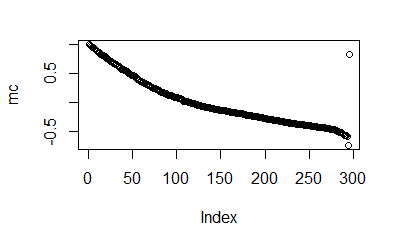

```r
# Calculate Moran's coefficient for eigenvectors
mc <- numeric()
for(i in 3:ncol(EV)){
  junk <- moran(EV[,i], tazw, length(EV), Szero(tazw))
  mc[i-2] <- as.numeric(junk[1])
}
# Plot Moran's coefficients
plot(mc)
```

Select vector to use:

```r
SEV <- select(EV, VAR1 = MEM3, VAR2 = MEM120)
```

Add randomness to the selected eigenvector and normalize again:

```r
SEV <- mutate(SEV, VAR3 = VAR1 + 2 * runif(297), VAR4 = VAR1 + 5 * runif(297), VAR5 = VAR2 + 2 * runif(297))
maxs <- apply(SEV, 2, max)
mins <- apply(SEV, 2, min)
SEV <- as.data.frame(scale(SEV, center = mins, scale = maxs - mins))
```

Add the zone identifiers to the dataframe with the selected eigenvectors:

```r
SEV$GTA06 <- taz@data$GTA06
```

Add vectors to the tidied dataframe:

```r
taz.t <- left_join(taz.t, SEV, by = "GTA06")
```

```
Column `GTA06` joining character vector and factor, coercing into character vector
```

Create maps!

Obtain a base map. For this, the argument must specify the location for the capture. The outcome can be saved as an object that can later be used for mapping:

```r
hamilton <- get_map("Hamilton, Ontario")
```

The function `ggmap` allows you to create a base map to which other geometric objects (or geoms, in the terminology of `ggplot2`) can be added as layers. For instance, plot the traffic analysis zones on your base map:

```r
ggmap(hamilton, extent = "panel") +
  geom_polygon(data = taz.t, aes(x = long, y = lat, group = group), colour = 'black', alpha = .3, size = .3)
```

[output not shown]

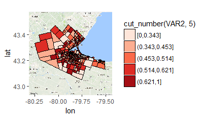

```r
ggmap(hamilton, extent = "panel") +
  geom_polygon(data = taz.t, aes(x = long, y = lat, group = group, fill = cut_number(VAR2, 5)), colour = 'black', alpha = 1, size = .3) +
  scale_fill_brewer(palette = "Reds")
```

Save the dataset for use in the activity:

```r
HamiltonDAs <- taz.t
save(HamiltonDAs, file = "HamiltonDAs.RData")
```